# Quick Analysis Using msleep Data

Victoria Liebsch-Aljawahiri

2022-09-12

## Perparations

Load required libraries and custom functions.

```r
library(dplyr)
library(ggplot2)

# Functions
# Theme for plot
cool_theme <- function() {
  theme_minimal() +
  theme(
    text = element_text(family = "Bookman", color = "gray25"),
    plot.subtitle = element_text(size = 12),
    plot.caption = element_text(color = "gray30"),
    plot.background = element_rect(fill = "gray95"),
    plot.margin = unit(c(5, 10, 5, 10), units = "mm")
  )
}
```

## Question 1

DataCamp completion of “Intermediate R” and “Data Manipulation with dyplr”.

### The following questions will use the built-in dataset `msleep`.

## Question 2

Calculate the proportion of each category of `vore` as a percentage and visualize the results using a bar chart. Comment on the results.

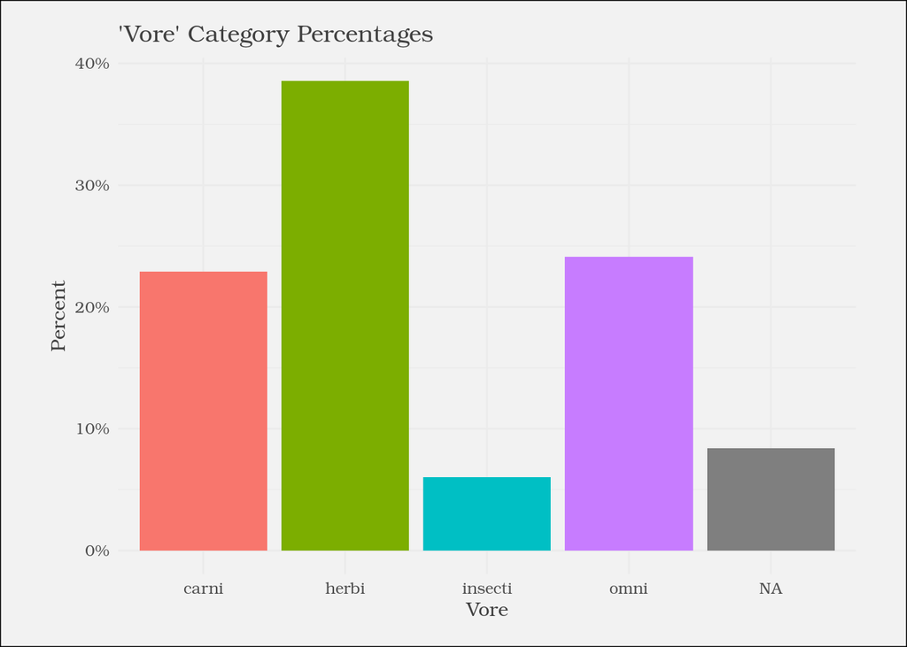

```r
ggplot(msleep, aes(x = vore, y = percent, fill = vore)) +
  geom_bar(aes(y=(after_stat(count))/sum(after_stat(count))), show.legend = FALSE) +
  scale_y_continuous(labels = scales::percent) +
  cool_theme() +
  labs(title = "'Vore' Category Percentages",
       x = "Vore",
       y = "Percent")
```

According to the results visualized by the bar chat above, we can see that herbivores (`herbi`) are the most prevalent in the data collected. This makes up over one-third or about 38% of the mammals. Carnivores (`carni`) and omnivores (`omni`) are about the same percentage at around 24%, with there being slightly more omnivores. There also is an unspecified column (`NA`) which is the four prevalent, making up about 8% of the data. This means that the “-vore” of a mammal was not specified or documented. The least prevalent of all mammals are the insectivores (`insecti`), which amount to about 6%.

## Question 3

Filter the data to extract data for just omnivores. Hint: vore == ‘herbi’ and vore == ‘carni’. Calculate the mean `sleep_total` for that group.

```r
msleep %>%
  filter(vore == "omni") %>%
  summarize(mean(sleep_total))
```

| mean(sleep_total) |
| --- |
| 10.925 |

The mean `sleep_total` for omnivores in the `msleep` data is 10.925 hours.

## Question 4

Create a scatterplot showing the relationship between `bodywt` and `brainwt`. Comment on any correlation that is visually apparent. Tip: if you rescale the x and y axis using a logarithmic scale, it may help you to interpret the visualization better e.g. you can append the following to ggplot: scale_x_log10() and scale_y_log10().

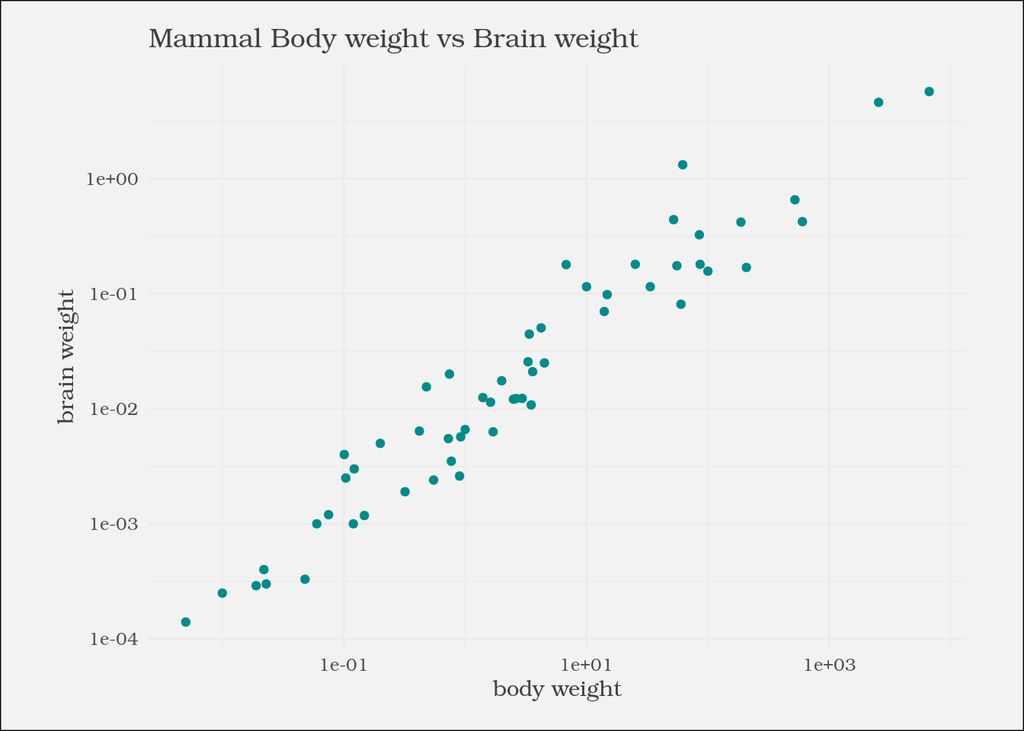

```r
ggplot(msleep, aes(x = bodywt, y = brainwt)) +
  geom_point(na.rm = TRUE, color = "darkcyan") +
  scale_x_log10() +
  scale_y_log10() +
  cool_theme() +
  labs(title = "Mammal Body weight vs Brain weight",
       x = "body weight",
       y = "brain weight")
```

The graph above shows a significant correlation between `bodywt` and `brainwt`. It is shown that as the body weight of a mammal increases so does their brain weight.

## Question 5

Calculate the Pearson coefficient of correlation in R, to evaluate the strength of the correlation between `bodywt` and `brainwt`. Did the results support your original assumptions from question 4?

```r
cor(log10(msleep$bodywt),msleep$brainwt,use = "complete.obs")
```

```
## [1] 0.5548935
```

The calculated Pearson coefficient of correlation for `bodywt` and `brainwt` is greater than 0.5, thus indicating a strong positive correlation. These results support my original assumptions from question 4.

## Question 6

Determine which mammals are outliers in terms of `sleep_total`. Outliers, for the sake of this question, are defined as values that are more than 1.5 standard deviations from the mean. Display the `name` and `sleep_total` of the mammals which are outliers.

```r
mean_tsleep <- mean(msleep$sleep_total)
sd_tsleep <- sd(msleep$sleep_total)
msleep$z_score <- (abs(mean_tsleep - msleep$sleep_total) / sd_tsleep)

msleep %>%
  group_by(name) %>%
  filter(z_score > 1.5) %>%
  summarize(name, sleep_total)
```

| name | sleep_total |
| --- | --- |
| African elephant | 3.3 |
| Big brown bat | 19.7 |
| Caspian seal | 3.5 |
| Donkey | 3.1 |
| Giant armadillo | 18.1 |
| Giraffe | 1.9 |
| Horse | 2.9 |
| Little brown bat | 19.9 |
| Long-nosed armadillo | 17.4 |
| North American Opossum | 18.0 |

[output cut: 3 more lines]

As we can see from the output above, there are 13 mammals that classify as outliers in the `msleep` dataframe.